# `ddd`

[figure not shown]

## `Domain-driven Design (ddd)`

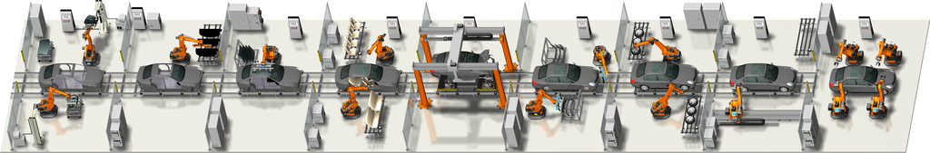

## Hurry please, I have a short attention span, what is `ddd`?

Sorry, most likely `ddd` is not for you.

## Who is `ddd` for?

Here are a few assumptions about you:

- You are an R user
- You are an experienced Data Scientist
- You have seen and created clunkers, that is, analytic applications with an abundance of cruft
- You have a passion for producing analytic applications of high-quality every day

If you belong to the intersection of all the sets above, then ddd may benefit you.

## What `ddd` is (but first, what it is not)

Because `ddd` is an R package that caters for Data Scientists, it is natural to think it may contain a new learning algorithm, statistical method, a visualisation tool, or data processing toolkit. `ddd` offers none of these things. Instead, `ddd` automates repetitive tasks that arise during software development in R. In that sense, `ddd` is akin to the [`usethis`](https://usethis.r-lib.org/) package.

`ddd` is an acronym of a software development approach called [**Domain-driven design**](https://en.wikipedia.org/wiki/Domain-driven_design), or DDD for short. `ddd` facilitates the implementation of key DDD patterns including Entity, Value Object and Domain Services. Together these building blocks form a domain model.

Before getting into specifics about **Domain-driven Design**, lets first discuss the importance of software design and how it is inevitable.

## Why should I use software design?

When you drive to a new place, especially if the destination is far or in an unfamiliar location, something guides you. It could be a GPS, a map or a friend sitting in the front seat. Have you ever tried driving to a new location without any guidance? If so, how well did it go for you?

When you develop software to solve a new business problem, what guides your software design? Obviously, you strive to eliminate unintended behaviours (bugs) from the software. Perhaps you are using tests and even a Test-Driven Development (TDD) approach. However, guiding your design with tests is analogous to driving a car by using the guardrails. It keeps you safe from the bar ditches while you drive, though it has no navigation utility.

## Installation

You can install `ddd` by using:

```r
install.packages("remotes")
remotes::install_github("tidylab/ddd")
```

Optionally, you can make a project independent of the `ddd` package by calling `use_ddd()`. `ddd` is needed for software development and has no added value in production. `use_ddd()` will copy the necessary R classes and functions into your project.